# 01. Shared processing: recount3 GTEx and TCGA inputs

Pan-cancer aging pipeline, Part 2

May 18, 2026

## Overview

This script prepares harmonized GTEx and TCGA inputs for the Part 2 analyses (gene-level age modeling and cell-type deconvolution). All downstream Part 2 scripts read from the outputs produced here.

Data are pulled from recount3 to keep the source consistent with the clock training pipeline. For each retained project we save a protein-coding, gene-symbol-collapsed count matrix together with sample-level metadata (age, sex, sample type).

A few methodological choices are made here and inherited by every downstream Part 2 script:

- **Protein-coding only.** Matches the gene universe used for clock training and reduces noise from low-coverage non-coding annotations.
- **Drop pseudoautosomal Y duplicates (`_PAR_Y`).** Same convention as the clock pipeline; avoids double-counting reads.
- **Duplicate symbol collapse via row sums.** The clock pipeline collapses logCPM duplicates by mean, since averaging is the right operation on a log scale. This script collapses raw counts by sum, since summed reads is what DESeq2 expects.
- **Retain primary disease samples.** For solid tumors that is `Primary Tumor`. We additionally retain `Primary Blood Derived Cancer - Peripheral Blood` so that TCGA-LAML is included in pan-cancer summaries. Solid-tissue normal and metastatic samples are excluded.
- **Minimum sample threshold.** Projects with fewer than 50 samples with non-missing age are flagged in the manifest but skipped for downstream modeling.
- **Minimal covariate metadata.** We retain only age and sex. Additional TCGA-only covariates (purity, grade, stage) are intentionally not used in Part 2, so that GTEx and TCGA can be modeled symmetrically. Compositional concerns are addressed separately via cell-type deconvolution.

Outputs are written to `results/derived/part2/01_processing/` and `results/tables/part2/`.

## Libraries

```r
suppressPackageStartupMessages({
  library(recount3)
  library(SummarizedExperiment)
  library(dplyr)
  library(tibble)
  library(purrr)
  library(ggplot2)
  library(reactable)
  library(here)
})
```

## Setup

```r
set.seed(params$seed)

derived_root <- here::here(params$out_root)
tables_root  <- here::here(params$tables_root)
cache_root   <- here::here("data", "recount3_cache")

dir.create(derived_root, recursive = TRUE, showWarnings = FALSE)
dir.create(tables_root,  recursive = TRUE, showWarnings = FALSE)
dir.create(cache_root,   recursive = TRUE, showWarnings = FALSE)

Sys.setenv(
  R_USER_CACHE_DIR = cache_root,
  BIOC_FILE_CACHE  = cache_root
)

msg <- function(...) {
  if (isTRUE(params$verbose)) message(...)
}
```

## Helpers

```r
reactable_pretty <- function(df) {
  reactable::reactable(
    df,
    searchable = TRUE,
    resizable = TRUE,
    defaultPageSize = 10
  )
}

# Collapse recount3 rowData to a protein-coding, symbol-level count matrix.
# Duplicate symbols are summed (appropriate for raw-count input).
sym_counts_from_rse <- function(rse, protein_coding_only = TRUE, drop_par_y = TRUE) {
  stopifnot("counts" %in% assayNames(rse))

  rd  <- as.data.frame(rowData(rse))
  mat <- assay(rse, "counts")

  keep <- !is.na(rd$gene_name) & rd$gene_name != ""

  if (protein_coding_only) {
    if (!"gene_type" %in% colnames(rd)) {
      stop("rowData(rse)$gene_type not found; cannot filter to protein-coding genes.")
    }
    keep <- keep & rd$gene_type == "protein_coding"
  }

  if (drop_par_y && "gene_id" %in% colnames(rd)) {
    keep <- keep & !grepl("_PAR_Y$", rd$gene_id)
  }

  mat_keep <- mat[keep, , drop = FALSE]
  syms     <- rd$gene_name[keep]

  rowsum(mat_keep, group = syms)
}

normalize_sex_gtex <- function(x) {
  out <- dplyr::case_when(
    x == 1 ~ "Male",
    x == 2 ~ "Female",
    TRUE   ~ NA_character_
  )
  factor(out, levels = c("Female", "Male"))
}

normalize_sex_tcga <- function(x) {
  out <- dplyr::case_when(
    x %in% c("MALE", "Male", "male", "M")       ~ "Male",
    x %in% c("FEMALE", "Female", "female", "F") ~ "Female",
    TRUE                                        ~ NA_character_
  )
  factor(out, levels = c("Female", "Male"))
}

load_one_project <- function(project_code, projects_df) {
  info <- dplyr::filter(projects_df, project == project_code)
  if (nrow(info) == 0) stop("No rows found for project: ", project_code)
  recount3::create_rse(info)
}
```

## Identify recount3 projects

```r
human_projects <- recount3::available_projects()

gtex_projects <- human_projects %>%
  dplyr::filter(
    project_type == "data_sources",
    grepl("gtex", project_home, ignore.case = TRUE),
    project != "STUDY_NA"
  )

tcga_projects <- human_projects %>%
  dplyr::filter(
    project_type == "data_sources",
    grepl("tcga", project_home, ignore.case = TRUE)
  )

gtex_tissues <- sort(unique(gtex_projects$project))
tcga_cancers <- sort(unique(tcga_projects$project))
```

GTEx tissues available: 31. TCGA cancers available: 33.

## Load GTEx phenotype metadata

GTEx age and sex are pulled from the protected subject-level annotations file (v10 release).

```r
if (!file.exists(params$gtex_age_tsv)) {
  stop("GTEx phenotype file not found: ", params$gtex_age_tsv)
}

gtex_pheno <- read.delim(
  params$gtex_age_tsv,
  stringsAsFactors = FALSE,
  check.names = FALSE
)

if (!all(c("SUBJID", "AGE", "SEX") %in% colnames(gtex_pheno))) {
  stop("GTEx phenotype file must contain SUBJID, AGE, and SEX.")
}
```

## Process GTEx tissues

```r
process_one_gtex <- function(tissue) {
  msg("Processing GTEx tissue: ", tissue)

  rse <- load_one_project(tissue, gtex_projects)
  assay(rse, "counts") <- recount3::transform_counts(rse)

  age_idx <- match(colData(rse)$gtex.subjid, gtex_pheno$SUBJID)
  colData(rse)$age_years <- as.numeric(gtex_pheno$AGE[age_idx])
  colData(rse)$sex       <- normalize_sex_gtex(gtex_pheno$SEX[age_idx])

  n_total    <- ncol(rse)
  n_with_age <- sum(is.finite(colData(rse)$age_years))
  n_female   <- sum(colData(rse)$sex == "Female", na.rm = TRUE)
  n_male     <- sum(colData(rse)$sex == "Male",   na.rm = TRUE)

  dir_proj <- file.path(derived_root, "GTEx", tissue)
  dir.create(dir_proj, recursive = TRUE, showWarnings = FALSE)

  kept <- n_with_age >= params$min_samples_with_age

  if (kept) {
    counts_sym <- sym_counts_from_rse(rse)

    metadata <- tibble::tibble(
      sample_id   = colnames(rse),
      cohort      = "GTEx",
      project     = tissue,
      age_years   = as.numeric(colData(rse)$age_years),
      sex         = as.character(colData(rse)$sex),
      gtex.subjid = as.character(colData(rse)$gtex.subjid)
    )

    saveRDS(counts_sym, file.path(dir_proj, "counts_sym.rds"))
    saveRDS(metadata,   file.path(dir_proj, "sample_metadata.rds"))
  }

  tibble::tibble(
    cohort        = "GTEx",
    project       = tissue,
    n_total       = n_total,
    n_with_age    = n_with_age,
    n_female      = n_female,
    n_male        = n_male,
    kept          = kept,
    counts_file   = if (kept) file.path(dir_proj, "counts_sym.rds")   else NA_character_,
    metadata_file = if (kept) file.path(dir_proj, "sample_metadata.rds") else NA_character_
  )
}

gtex_manifest <- purrr::map_dfr(gtex_tissues, process_one_gtex)
```

## Process TCGA cancers

```r
process_one_tcga <- function(cancer) {
  msg("Processing TCGA cancer: ", cancer)

  rse <- load_one_project(cancer, tcga_projects)

  sample_type_all <- if ("tcga.cgc_sample_sample_type" %in% colnames(colData(rse))) {
    as.character(colData(rse)$tcga.cgc_sample_sample_type)
  } else {
    rep(NA_character_, ncol(rse))
  }

  keep_primary <- sample_type_all %in% unlist(params$tcga_keep_sample_types)
  rse <- rse[, keep_primary, drop = FALSE]
  sample_type <- sample_type_all[keep_primary]

  assay(rse, "counts") <- recount3::transform_counts(rse)

  colData(rse)$age_years <- suppressWarnings(
    as.numeric(colData(rse)$tcga.cgc_case_age_at_diagnosis)
  )
  colData(rse)$sex <- normalize_sex_tcga(colData(rse)$tcga.cgc_case_gender)

  n_total    <- ncol(rse)
  n_with_age <- sum(is.finite(colData(rse)$age_years))
  n_female   <- sum(colData(rse)$sex == "Female", na.rm = TRUE)
  n_male     <- sum(colData(rse)$sex == "Male",   na.rm = TRUE)

  dir_proj <- file.path(derived_root, "TCGA", cancer)
  dir.create(dir_proj, recursive = TRUE, showWarnings = FALSE)

  kept <- n_with_age >= params$min_samples_with_age

  if (kept) {
    counts_sym <- sym_counts_from_rse(rse)

    tcga_barcode <- if ("tcga.tcga_barcode" %in% colnames(colData(rse))) {
      as.character(colData(rse)$tcga.tcga_barcode)
    } else {
      rep(NA_character_, ncol(rse))
    }

    metadata <- tibble::tibble(
      sample_id         = colnames(rse),
      cohort            = "TCGA",
      project           = cancer,
      age_years         = as.numeric(colData(rse)$age_years),
      sex               = as.character(colData(rse)$sex),
      sample_type       = sample_type,
      tcga.tcga_barcode = tcga_barcode
    )

    saveRDS(counts_sym, file.path(dir_proj, "counts_sym.rds"))
    saveRDS(metadata,   file.path(dir_proj, "sample_metadata.rds"))
  }

  tibble::tibble(
    cohort        = "TCGA",
    project       = cancer,
    n_total       = n_total,
    n_with_age    = n_with_age,
    n_female      = n_female,
    n_male        = n_male,
    kept          = kept,
    counts_file   = if (kept) file.path(dir_proj, "counts_sym.rds")    else NA_character_,
    metadata_file = if (kept) file.path(dir_proj, "sample_metadata.rds") else NA_character_
  )
}

tcga_manifest <- purrr::map_dfr(tcga_cancers, process_one_tcga)
```

## Sample inventory

The two tables below list every project the pipeline considered, the number of samples retained after applying the primary-disease filter (TCGA) or default inclusion rules (GTEx), and the number of samples with non-missing chronological age.

### GTEx

```r
gtex_display <- gtex_manifest %>%
  dplyr::transmute(
    Tissue     = project,
    n_samples  = n_total,
    n_with_age = n_with_age,
    n_female   = n_female,
    n_male     = n_male,
    Retained   = kept
  )

reactable_pretty(gtex_display)
```

| Tissue | n_samples | n_with_age | n_female | n_male | Retained |
| --- | --- | --- | --- | --- | --- |
| ADIPOSE_TISSUE | 1293 | 1293 | 430 | 863 | True |
| ADRENAL_GLAND | 274 | 274 | 106 | 168 | True |
| BLADDER | 21 | 21 | 7 | 14 | False |
| BLOOD | 1048 | 1048 | 364 | 684 | True |
| BLOOD_VESSEL | 1398 | 1398 | 482 | 916 | True |
| BONE_MARROW | 204 | 0 | 0 | 0 | False |
| BRAIN | 2931 | 2931 | 836 | 2095 | True |
| BREAST | 482 | 482 | 180 | 302 | True |
| CERVIX_UTERI | 19 | 19 | 19 | 0 | False |
| COLON | 822 | 822 | 294 | 528 | True |

[output cut: 21 more lines]

GTEx tissues retained for downstream analyses: **27 of 31**.

### TCGA

```r
tcga_display <- tcga_manifest %>%
  dplyr::transmute(
    Cancer     = project,
    n_samples  = n_total,
    n_with_age = n_with_age,
    n_female   = n_female,
    n_male     = n_male,
    Retained   = kept
  )

reactable_pretty(tcga_display)
```

| Cancer | n_samples | n_with_age | n_female | n_male | Retained |
| --- | --- | --- | --- | --- | --- |
| ACC | 79 | 79 | 48 | 31 | True |
| BLCA | 414 | 414 | 109 | 305 | True |
| BRCA | 1127 | 1117 | 1105 | 12 | True |
| CESC | 304 | 304 | 304 | 0 | True |
| CHOL | 36 | 36 | 20 | 16 | False |
| COAD | 503 | 500 | 239 | 261 | True |
| DLBC | 48 | 47 | 26 | 21 | False |
| ESCA | 184 | 184 | 26 | 158 | True |
| GBM | 157 | 156 | 54 | 102 | True |
| HNSC | 502 | 501 | 133 | 368 | True |

[output cut: 23 more lines]

TCGA cancers retained for downstream analyses: **31 of 33**.

## Covariates available for Part 2 modeling

Downstream Part 2 models (DESeq2 for gene-level age effects, sccomp for compositional age effects) use the covariates listed here. The same minimal-covariate framework is applied in both cohorts so that GTEx and TCGA results are directly comparable.

```r
covariate_summary <- tibble::tribble(
  ~Covariate,           ~GTEx,                                   ~TCGA,                                       ~Use,
  "Chronological age",  "Subject phenotype file (v10)",          "tcga.cgc_case_age_at_diagnosis",            "Primary predictor in all Part 2 models",
  "Sex",                "Subject phenotype file (v10)",          "tcga.cgc_case_gender",                      "Adjusted for when both sexes are represented",
  "Project / tissue",   "GTEx tissue label",                     "TCGA cancer code",                          "Stratification variable for per-project models"
)

reactable_pretty(covariate_summary)
```

| Covariate | GTEx | TCGA | Use |
| --- | --- | --- | --- |
| Chronological age | Subject phenotype file (v10) | tcga.cgc_case_age_at_diagnosis | Primary predictor in all Part 2 models |
| Sex | Subject phenotype file (v10) | tcga.cgc_case_gender | Adjusted for when both sexes are represented |
| Project / tissue | GTEx tissue label | TCGA cancer code | Stratification variable for per-project models |

Additional TCGA-only covariates such as tumor purity, grade, and stage are intentionally excluded from Part 2 modeling to preserve symmetric comparison with GTEx. Compositional confounding is addressed separately through cell-type deconvolution.

## Age distribution across cohorts

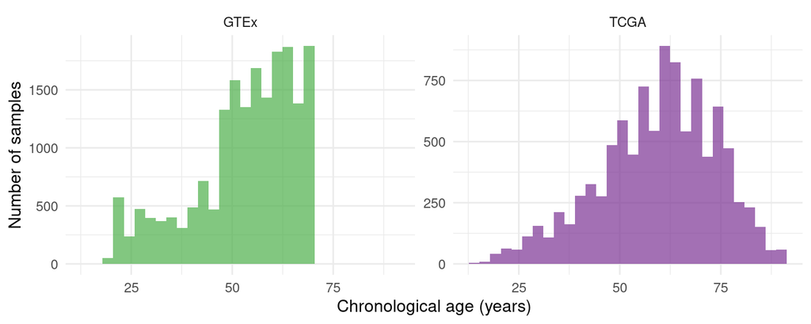

```r
age_df <- dplyr::bind_rows(
  gtex_manifest %>%
    dplyr::filter(kept) %>%
    purrr::pmap_dfr(function(metadata_file, ...) {
      readRDS(metadata_file) %>% dplyr::select(age_years) %>% dplyr::mutate(Cohort = "GTEx")
    }),
  tcga_manifest %>%
    dplyr::filter(kept) %>%
    purrr::pmap_dfr(function(metadata_file, ...) {
      readRDS(metadata_file) %>% dplyr::select(age_years) %>% dplyr::mutate(Cohort = "TCGA")
    })
) %>%
  dplyr::filter(is.finite(age_years))

ggplot(age_df, aes(x = age_years, fill = Cohort)) +
  geom_histogram(bins = 30, alpha = 0.7, position = "identity") +
  facet_wrap(~ Cohort, nrow = 1, scales = "free_y") +
  scale_fill_manual(values = c(GTEx = "#4daf4a", TCGA = "#7b3294")) +
  theme_minimal(base_size = 12) +
  labs(
    x = "Chronological age (years)",
    y = "Number of samples",
    fill = NULL
  ) +
  theme(legend.position = "none")
```

GTEx and TCGA cover overlapping but not identical age ranges. GTEx samples skew toward middle and older age (the donor population is post-mortem), while TCGA covers a wider span anchored on adult cancer onset.

## Save manifest

```r
project_manifest <- dplyr::bind_rows(gtex_manifest, tcga_manifest) %>%
  dplyr::arrange(cohort, project)

saveRDS(
  project_manifest,
  file = file.path(derived_root, "project_manifest.rds")
)

utils::write.csv(
  project_manifest,
  file = file.path(tables_root, "part2_processing_manifest.csv"),
  row.names = FALSE
)

msg("Saved processing outputs to: ", derived_root)
```